# QK Box 10.6

Caballes et al. (2016) examined the effects of maternal nutrition (three treatments: starved or fed one of two coral genera: *Acropora* or *Porites*) on the larval biology of crown-of-thorns seastars. There were three female seastars nested within each treatment, 50 larvae reared from each female were placed into each of three glass culture jars and the lengths of ten larvae from each jar after four days were measured after 4 days. This fully balanced design has maternal nutrition as a fixed factor with three random levels of nesting: females within nutrition treatment, jars within females and individual larvae within jars.

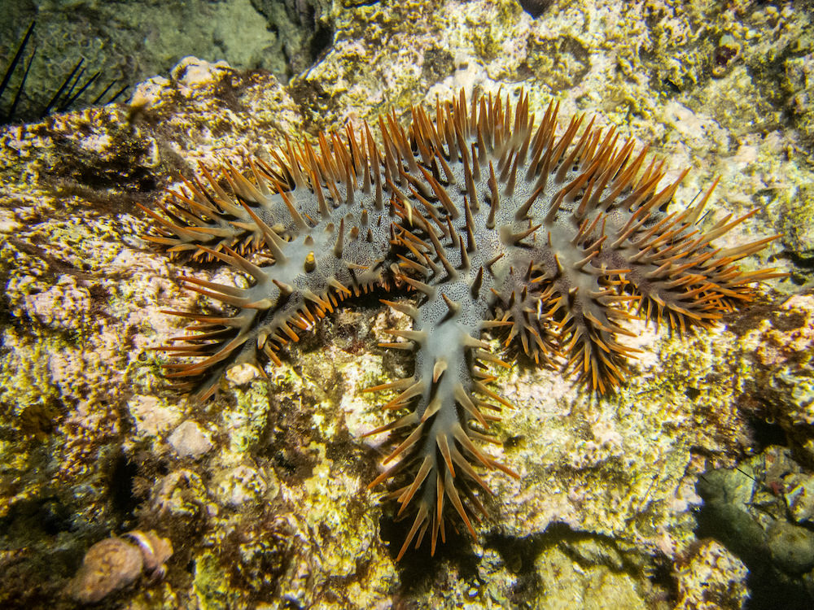

Crown of thorns seastar, Acanthaster planci. Mick Keough, [CC BY 4.0](https://creativecommons.org/licenses/by-sa/4.0)

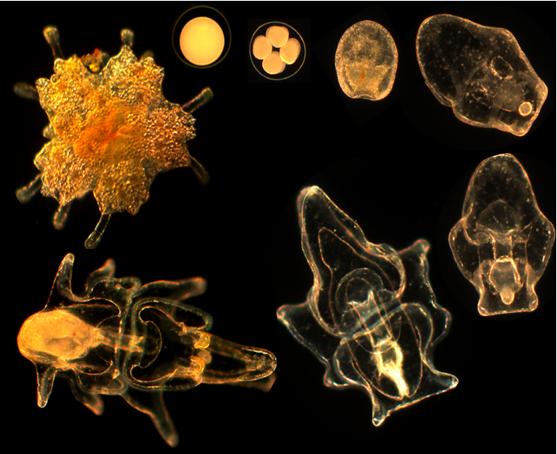

Larval cycle of crown-of-thorns. AIMS, [CC BY 4.0](https://creativecommons.org/licenses/by-sa/4.0)

The paper is here

Caballes, C. F., Pratchett, M. S., Kerr, A. M. & Rivera-Posada, J. A. (2016). The role of maternal nutrition on oocyte size and quality, with respect to early larval development in the coral-eating starfish, *Acanthaster planci*. *PLoS One*, 11, e0158007.

### Preliminaries

First, load the required packages (afex, car, lattice, lme4, lmerTest, nlme, VCA, Rmisc)

Import caballes data file (caballes_length.csv)

```r
caballes_length <- read.csv("../data/caballes_length.csv")
head(caballes_length,10)
```

|  | diet | female | jar | length |
| --- | --- | --- | --- | --- |
| 1 | starved | 1 | 1 | 0.638 |
| 2 | starved | 1 | 1 | 0.533 |
| 3 | starved | 1 | 1 | 0.476 |
| 4 | starved | 1 | 1 | 0.359 |
| 5 | starved | 1 | 1 | 0.354 |
| 6 | starved | 1 | 1 | 0.576 |
| 7 | starved | 1 | 1 | 0.742 |
| 8 | starved | 1 | 1 | 0.495 |
| 9 | starved | 1 | 1 | 0.803 |
| 10 | starved | 1 | 1 | 0.493 |

```r
set_sum_contrasts()
```

```
setting contr.sum globally: options(contrasts=c('contr.sum', 'contr.poly'))
```

Make female and jar factors

```r
caballes_length$female <- factor(caballes_length$female)
caballes_length$jar <- factor(caballes_length$jar)
```

Reorder nutrition treatments so starved is first for default lm contrasts

```r
caballes_length$diet <- factor(caballes_length$diet, levels = c("starved","aa","pr"))
```

## Run model

**Note:** can’t get the aov commands to work for 3 level nested design

```r
caballes.aov <- aov(length~diet+Error(female/jar), caballes_length)
```

### Fit as lm using OLS estimation

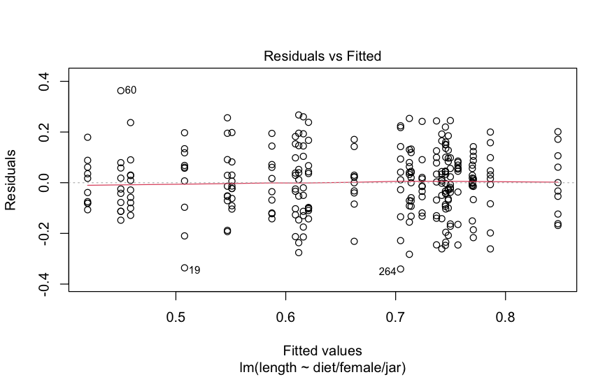

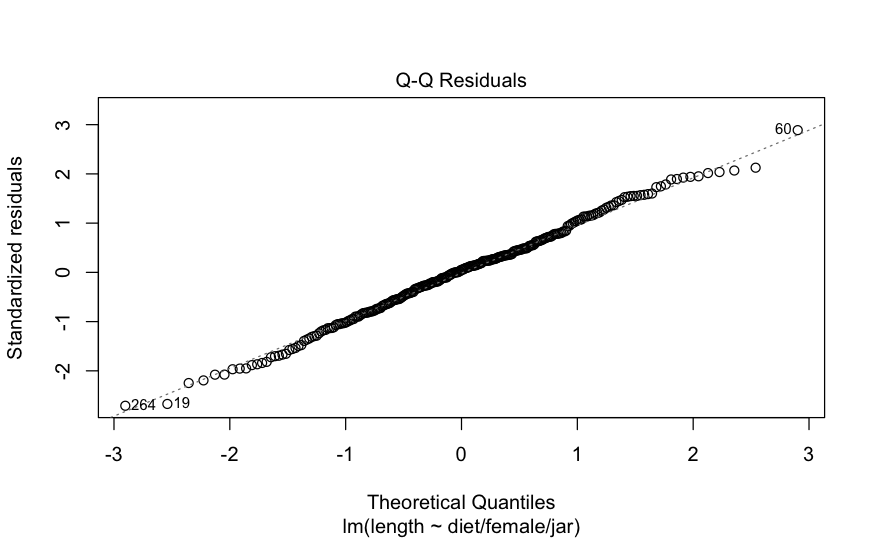

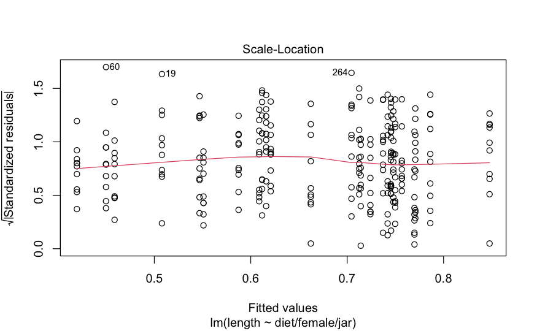

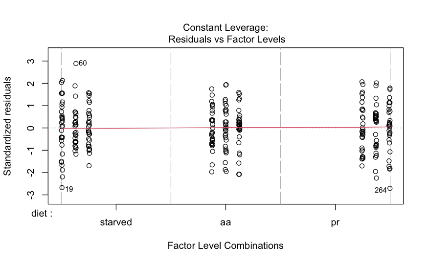

```r
caballes.lm <- lm(length ~ diet/female/jar, caballes_length)
plot(caballes.lm)
```

```r
summary(caballes.lm)
```

```
Call:
lm(formula = length ~ diet/female/jar, data = caballes_length)

Residuals:
    Min      1Q  Median      3Q     Max
-0.3405 -0.0840  0.0065  0.0801  0.3631

Coefficients: (702 not defined because of singularities)
                          Estimate Std. Error t value Pr(>|t|)
(Intercept)                 0.6899     0.0242   28.52   <2e-16 ***
diet1                      -0.1025     0.0342   -3.00    0.003 **
diet2                       0.0799     0.0342    2.34    0.020 *
dietstarved:female1         0.0244     0.0592    0.41    0.681
dietaa:female1                  NA         NA      NA       NA
dietpr:female1              0.0129     0.1026    0.13    0.900
dietstarved:female2        -0.1375     0.0592   -2.32    0.021 *
dietaa:female2                  NA         NA      NA       NA
dietpr:female2                  NA         NA      NA       NA
dietstarved:female3             NA         NA      NA       NA
dietaa:female3                  NA         NA      NA       NA
dietpr:female3                  NA         NA      NA       NA
dietstarved:female4             NA         NA      NA       NA
dietaa:female4             -0.0557     0.0592   -0.94    0.348
dietpr:female4                  NA         NA      NA       NA
dietstarved:female5             NA         NA      NA       NA
dietaa:female5             -0.0326     0.0592   -0.55    0.583
dietpr:female5                  NA         NA      NA       NA
dietstarved:female6             NA         NA      NA       NA
dietaa:female6                  NA         NA      NA       NA
dietpr:female6                  NA         NA      NA       NA
dietstarved:female7             NA         NA      NA       NA
dietaa:female7                  NA         NA      NA       NA
dietpr:female7              0.0373     0.0592    0.63    0.530
dietstarved:female8             NA         NA      NA       NA
dietaa:female8                  NA         NA      NA       NA
dietpr:female8                  NA         NA      NA       NA
dietstarved:female1:jar1   -0.0649     0.0592   -1.10    0.274
dietaa:female1:jar1             NA         NA      NA       NA
dietpr:female1:jar1             NA         NA      NA       NA
dietstarved:female2:jar1        NA         NA      NA       NA
```

[output cut: 161 more lines]

```
dietstarved:female2:jar7        NA         NA      NA       NA
dietaa:female2:jar7             NA         NA      NA       NA
dietpr:female2:jar7             NA         NA      NA       NA
dietstarved:female3:jar7   -0.0364     0.0592   -0.61    0.540
dietaa:female3:jar7             NA         NA      NA       NA
dietpr:female3:jar7             NA         NA      NA       NA
dietstarved:female4:jar7        NA         NA      NA       NA
dietaa:female4:jar7             NA         NA      NA       NA
 [ reached getOption("max.print") -- omitted 529 rows ]
---
Signif. codes:  0 ‘***’ 0.001 ‘**’ 0.01 ‘*’ 0.05 ‘.’ 0.1 ‘ ’ 1

Residual standard error: 0.132 on 243 degrees of freedom
Multiple R-squared:  0.446, Adjusted R-squared:  0.387
F-statistic: 7.52 on 26 and 243 DF,  p-value: <2e-16
```

```r
anova(caballes.lm)
```

```
Analysis of Variance Table

Response: length
                 Df Sum Sq Mean Sq F value Pr(>F)
diet              2   2.53   1.267   72.16 <2e-16 ***
diet:female       6   0.37   0.062    3.55 0.0022 **
diet:female:jar  18   0.53   0.029    1.67 0.0460 *
Residuals       243   4.27   0.018
---
Signif. codes:  0 ‘***’ 0.001 ‘**’ 0.01 ‘*’ 0.05 ‘.’ 0.1 ‘ ’ 1
```

Get F and P values using correct denominators

```r
#Diet F
f <- 1.26668/0.06224
pf(f, df1 = 2, df2 = 6, lower.tail = FALSE)
```

```
[1] 0.00212
```

```r
#Females F
f <- 0.06224/0.02925
pf(f, df1 = 6, df2 = 18, lower.tail = FALSE)
```

```
[1] 0.1
```

```r
#Jars F
f <- 0.02925/0.01755
pf(f, df1 = 18, df2 = 243, lower.tail = FALSE)
```

```
[1] 0.0459
```

Variance components from VCA

```r
caballes.vca <- anovaMM(length ~ diet/(female)/(jar), caballes_length)
caballes.vca
```

```
ANOVA-Type Estimation of Mixed Model:
--------------------------------------

    [Fixed Effects]

        int      dietaa      dietpr dietstarved
      0.527       0.219       0.189       0.000


    [Variance Components]

  Name            DF         SS       MS       VC       %Total    SD       CV[%]
1 total           200.914152                   0.019823 100       0.140793 21.242557
2 diet:female     6          0.37346  0.062243 0.0011   5.547827  0.033162 5.003435
3 diet:female:jar 18         0.526523 0.029251 0.00117  5.90134   0.034202 5.160385
4 error           243        4.265431 0.017553 0.017553 88.550832 0.132489 19.989554

Mean: 0.663 (N = 270)

Experimental Design: balanced  |  Method: ANOVA
```

```r
VCAinference(caballes.vca, alpha = 0.05, VarVC = TRUE, ci.method = "satterthwaite")
```

```
Inference from Mixed Model Fit
------------------------------

> VCA Result:
-------------

    [Fixed Effects]

        int      dietaa      dietpr dietstarved
      0.527       0.219       0.189       0.000


    [Variance Components]

  Name            DF       SS     MS     VC     %Total  SD     CV[%]   Var(VC)
1 total           200.9142               0.0198 100     0.1408 21.2426 0
2 diet:female     6        0.3735 0.0622 0.0011 5.5478  0.0332 5.0034  0
3 diet:female:jar 18       0.5265 0.0293 0.0012 5.9013  0.0342 5.1604  0
4 error           243      4.2654 0.0176 0.0176 88.5508 0.1325 19.9896 0

Mean: 0.663 (N = 270)

Experimental Design: balanced  |  Method: ANOVA


> VC:
-----
                Estimate     DF CI LCL CI UCL One-Sided LCL One-Sided UCL
total             0.0198 200.91 0.0165 0.0244        0.0169        0.0235
diet:female       0.0011   1.57 0.0003 0.1039        0.0003        0.0427
diet:female:jar   0.0012   2.80 0.0004 0.0188        0.0004        0.0112
error             0.0176 243.00 0.0148 0.0211        0.0152        0.0205

> SD:
-----
                Estimate     DF CI LCL CI UCL One-Sided LCL One-Sided UCL
total             0.1408 200.91 0.1283  0.156        0.1302         0.153
diet:female       0.0332   1.57 0.0164  0.322        0.0184         0.207
diet:female:jar   0.0342   2.80 0.0191  0.137        0.0210         0.106
error             0.1325 243.00 0.1217  0.145        0.1233         0.143

> CV[%]:
--------
                Estimate     DF CI LCL CI UCL One-Sided LCL One-Sided UCL
total              21.24 200.91  19.35   23.5         19.64          23.2
diet:female         5.00   1.57   2.47   48.6          2.77          31.2
diet:female:jar     5.16   2.80   2.88   20.7          3.16          16.0
error              19.99 243.00  18.36   21.9         18.61          21.6


95% Confidence Level
Satterthwaite methodology used for computing CIs
```

### Fit mixed effects model using REML/ML

```r
caballes.lmer <- lmer(length ~ diet + (1|female/jar), caballes_length)
summary(caballes.lmer)
```

```
Linear mixed model fit by REML. t-tests use Satterthwaite's method ['lmerModLmerTest']
Formula: length ~ diet + (1 | female/jar)
   Data: caballes_length

REML criterion at convergence: -289

Scaled residuals:
    Min      1Q  Median      3Q     Max
-2.6901 -0.6966  0.0139  0.6414  2.5937

Random effects:
 Groups     Name        Variance Std.Dev.
 jar:female (Intercept) 0.00117  0.0342
 female     (Intercept) 0.00110  0.0332
 Residual               0.01755  0.1325
Number of obs: 270, groups:  jar:female, 27; female, 9

Fixed effects:
            Estimate Std. Error      df t value Pr(>|t|)
(Intercept)   0.6628     0.0152  5.9999   43.65  9.7e-09 ***
diet1        -0.1359     0.0215  5.9999   -6.33  0.00073 ***
diet2         0.0830     0.0215  5.9999    3.87  0.00831 **
---
Signif. codes:  0 ‘***’ 0.001 ‘**’ 0.01 ‘*’ 0.05 ‘.’ 0.1 ‘ ’ 1

Correlation of Fixed Effects:
      (Intr) diet1
diet1  0.000
diet2  0.000 -0.500
```

Get F-ratio for diet test using lmerTest

```r
anova(caballes.lmer, ddf = "Kenward-Roger")
```

```
Type III Analysis of Variance Table with Kenward-Roger's method
     Sum Sq Mean Sq NumDF DenDF F value Pr(>F)
diet  0.714   0.357     2     6    20.4 0.0021 **
---
Signif. codes:  0 ‘***’ 0.001 ‘**’ 0.01 ‘*’ 0.05 ‘.’ 0.1 ‘ ’ 1
```

CI on variance components (remembering to square CIs from lmer which are in SD units)

```r
caballes.ci <- confint.merMod(caballes.lmer)
```

```
Computing profile confidence intervals ...
```

```r
caballes.vc <- (caballes.ci)^2
print(caballes.vc)
```

```
              2.5 %  97.5 %
.sig01      0.00000 0.00405
.sig02      0.00000 0.00318
.sigma      0.01477 0.02108
(Intercept) 0.40405 0.47600
diet1       0.03036 0.00951
diet2       0.00199 0.01474
```